# Web Scraping Project

Yisong Tao

11/13/2016

## Web scraping MyAnimeList.net

MyAnimelist.net scraped reviews and info of 5953 animes.  
1. web scraping  
2. reviews: EDA  
3. anime info: network graph eda  
4. predict anime score

1. web scraping Done with scrapy. Scraped 2 parts of MyAnimelist.net: anime reviews and anime info. 89244 reviews, 5953 anime info downloaded. Lesson learned:
- clean up data while scraping,
- store data in correct format – Json vs. csv -> list vs. data.frame.
2. reviews EDA

```r
library(ggplot2)
library(dplyr)
AnimeReviews <- readRDS("AnimeReviews/AnimeReviews.RDS")
summary(AnimeReviews)
```

```
##  anime_title            rating        anime_url         review_text
##  Length:89244       Min.   : 0.000   Length:89244       Length:89244
##  Class :character   1st Qu.: 6.000   Class :character   Class :character
##  Mode  :character   Median : 8.000   Mode  :character   Mode  :character
##                     Mean   : 7.545
##                     3rd Qu.: 9.000
##                     Max.   :10.000
##  review_time          reviewer           pic_url
##  Length:89244       Length:89244       Length:89244
##  Class :character   Class :character   Class :character
##  Mode  :character   Mode  :character   Mode  :character
##
##
##
##       date
##  Min.   :2006-11-07 00:00:00
##  1st Qu.:2012-01-06 00:00:00
##  Median :2014-04-01 00:00:00
##  Mean   :2013-08-25 01:41:54
##  3rd Qu.:2015-10-04 00:00:00
##  Max.   :2016-11-07 00:00:00
```

```r
#head(AnimeReviews)
summ_review <- AnimeReviews %>%
    select(anime_title) %>%
    group_by(anime_title) %>%
    summarise(Count = n()) %>%
    arrange(desc(Count))
summary(summ_review$Count)
```

```
##    Min. 1st Qu.  Median    Mean 3rd Qu.    Max.
##    1.00    1.00    3.00   15.02   11.00 1112.00
```

```r
head(summ_review, 3)
```

```
## # A tibble: 3 × 2
##        anime_title Count
##              <chr> <int>
## 1 Sword Art Online  1112
## 2     Angel Beats!   731
## 3       Death Note   656
```

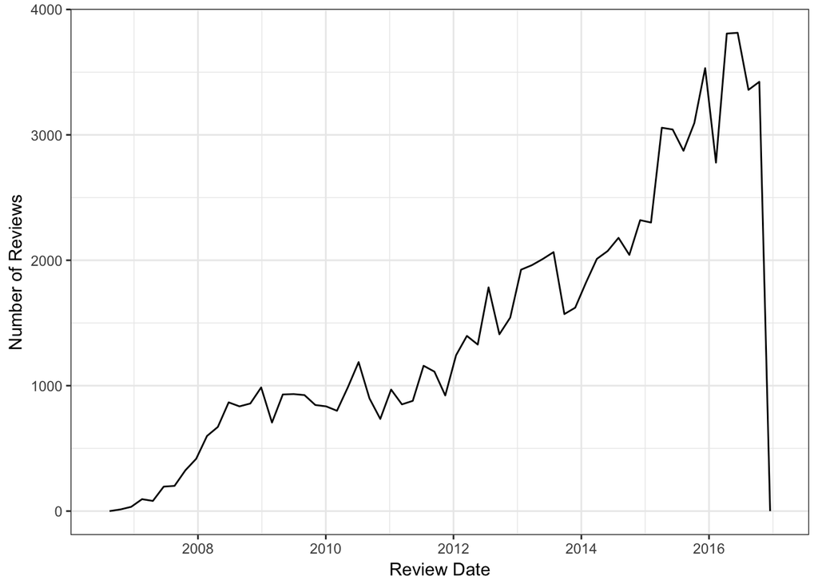

```r
p1 <- ggplot(AnimeReviews) +
    geom_freqpoly(aes(x=date), bins = 60) +
    xlab("Review Date") + ylab("Number of Reviews") +
    theme_bw()
p1
```

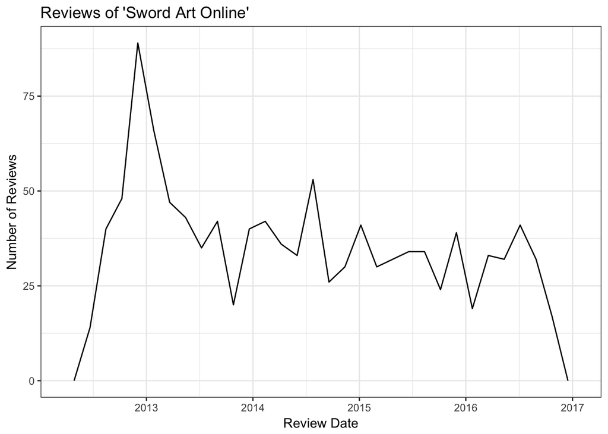

```r
review1 <- AnimeReviews[AnimeReviews$anime_title == "Sword Art Online", ]
p2 <- ggplot(review1) +
    geom_freqpoly(aes(x=date), bins = 30) +
    xlab("Review Date") + ylab("Number of Reviews") +
    theme_bw() + ggtitle("Reviews of 'Sword Art Online'")
p2
```

This anime started airing in Summer 2012, ended in Dec 2012. A short film aired in Dec 2013 and its sequel air in Summer 2014. Rumors of new sequel and movie project started in late 2016.

3. anime info EDA

```r
library(visNetwork)
library(car)
AnimeInfo <- readRDS("AnimeInfo/AnimeInfo.RDS")
length(AnimeInfo)
```

```
## [1] 5953
```

```r
names(AnimeInfo[[1]])
```

```
##  [1] "anime_title"      "anime_status"     "anime_popularity"
##  [4] "anime_studios"    "anime_genres"     "anime_favorites"
##  [7] "anime_synopsis"   "anime_aired"      "anime_premiered"
## [10] "anime_related"    "anime_mainactors" "anime_producers"
## [13] "anime_score"      "anime_ranked"     "anime_staff"
## [16] "anime_rating"     "anime_background" "anime_episodes"
## [19] "anime_type"       "anime_members"
```

```r
set.seed(0)
graph_list <- sample(AnimeInfo, 100)  ##randomly choose 100 anime for network graph
mklink_lst <- function(lst){
    link_list <- data.frame(from = numeric(), to = numeric(),
                            value = numeric(), title = character())
    l <- length(lst)
    #########check common elements in staff and cast members #####################################
    actor_lst <-lapply(lst, function(x) x$anime_mainactors)
    staff_lst <-lapply(lst, function(x) unlist(x$anime_staff))
    for (i in c(1:l-1)){
        for (j in c(i+1:l)){
            temp_actor <- intersect(unlist(actor_lst[i]), unlist(actor_lst[j]))
            temp_staff <- intersect(unlist(staff_lst[i]), unlist(staff_lst[j]))
            if (length(temp_actor) > 0 | length(temp_staff) > 0){
                if (length(temp_actor) > 0){
                    title_actor_temp <- paste0("Cast: ", temp_actor, collapse = '<br>')
                }
                if (length(temp_staff) > 0){
                    title_staff_temp <- paste0("Staff: ", temp_staff, collapse = '<br>')
                }
                if (length(temp_actor) > 0 & length(temp_staff) > 0){
                    title_temp <- paste0(title_staff_temp,'<br>', title_actor_temp)
                    value_t <- length(temp_staff) + length(temp_actor)
                }else if (length(temp_actor) > 0){
                    title_temp <- title_actor_temp
                    value_t <- length(temp_actor)
                }else{
                        title_temp <- title_staff_temp
                        value_t <- length(temp_staff)
                        }
                row <- data.frame(from = i, to = j,
                                  value = value_t, title = title_temp)
                link_list <- rbind(link_list, row)
            }
        }
    }
    return(link_list)
}

mknode_lst <- function(lst){
    node_list <- data.frame(ID = c(1:length(lst)))
    titles <- unlist(lapply(lst, function(x) x$anime_title))
    node_list$Titles <- titles
    types <- unlist(lapply(lst, function(x) x$anime_type))
    node_list$Types <- types
    members <- unlist(lapply(lst, function(x) x$anime_members))
    members <- as.numeric(gsub("\\,", "", members))
    node_list$Members <- members
    colnames(node_list) <- c("id", "title", "group", "size")
    node_list$size <- 2*sqrt(sqrt(node_list$size))
    node_list$label <- NA
    return(node_list)
}
link_list <- mklink_lst(graph_list)
node_list<- mknode_lst(graph_list)
graph <- visNetwork(nodes = node_list, edges = link_list, main = "Network of 100 Anime") %>%
    visNodes(label = NULL) %>%
    visLegend(enabled = TRUE, useGroups = TRUE, addNodes = NULL,
              addEdges = NULL, width = 0.2, position = "left", main = NULL) %>%
    visOptions(selectedBy = "group", highlightNearest = TRUE)
graph
```

[interactive chart not shown]

4. predict anime score

```r
Title <- unlist(lapply(AnimeInfo, function(x) x$anime_title))
Type <- unlist(lapply(AnimeInfo, function(x) x$anime_type))
Rating <- unlist(lapply(AnimeInfo, function(x) x$anime_rating))
Viewer <-unlist(lapply(AnimeInfo, function(x) as.numeric(gsub("\\,", "", x$anime_members))))
Score <- unlist(lapply(AnimeInfo, function(x) as.numeric(x$anime_score)))
Favorite <- unlist(lapply(AnimeInfo, function(x) as.numeric(gsub("\\,", "", x$anime_favorites))))
Actor1_lst <- lapply(AnimeInfo, function(x) x$anime_mainactor[1])
flag <- unlist(lapply(Actor1_lst, function(x) is.null(x[[1]])))
Actor1_lst[flag] <- NA
Actor1 <- unlist(Actor1_lst)
Actor2_lst <- lapply(AnimeInfo, function(x) x$anime_mainactor[2])
flag <- unlist(lapply(Actor2_lst, function(x) is.null(x[[1]])))
Actor2_lst[flag] <- NA
Actor2 <- unlist(Actor2_lst)
Actor3_lst <- lapply(AnimeInfo, function(x) x$anime_mainactor[3])
flag <- unlist(lapply(Actor3_lst, function(x) is.null(x[[1]])))
Actor3_lst[flag] <- NA
Actor3 <- unlist(Actor3_lst)
Actor4_lst <- lapply(AnimeInfo, function(x) x$anime_mainactor[4])
flag <- unlist(lapply(Actor4_lst, function(x) is.null(x[[1]])))
Actor4_lst[flag] <- NA
Actor4 <- unlist(Actor4_lst)
Director_lst <- lapply(AnimeInfo, function(x) x$anime_staff$Director)
flag <- unlist(lapply(Director_lst, function(x) is.null(x[[1]])))
Director_lst[flag] <- NA
Director <- unlist(Director_lst)
Musician_lst <- lapply(AnimeInfo, function(x) x$anime_staff$Music)
flag <- unlist(lapply(Musician_lst, function(x) is.null(x[[1]])))
Musician_lst[flag] <- NA
Musician <- unlist(Musician_lst)
AnimeInfo_df <- data.frame(Title = Title, Type = Type, Rating = Rating,
                           Director = Director, Actor1 = Actor1,
                           Actor2 = Actor2, Actor3 = Actor3,
                           Actor4 = Actor4, Musician = Musician,
                           Score = Score,
                           Viewer = Viewer, Favorite = Favorite
                           )
table(AnimeInfo_df$Rating)
```

```
##
##                   G - All Ages                           None
##                            686                             31
##                  PG - Children      PG-13 - Teens 13 or older
##                            351                           2815
## R - 17+ (violence & profanity)               R+ - Mild Nudity
##                            722                            628
##                    Rx - Hentai
##                            720
```

```r
#Upon investigation, all animes missing 'Rating' are old animes produced before rating system came and they all look #like "G"-rating animes.
#Set all their ratings to "G - All Ages".
AnimeInfo_df$Rating[AnimeInfo_df$Rating== "None"] <- "G - All Ages"
AnimeInfo_df$Rating <- as.character(AnimeInfo_df$Rating)
AnimeInfo_df$Rating <- as.factor(AnimeInfo_df$Rating)
sum_AnimeInfo <- AnimeInfo_df %>%
    group_by(Type) %>%
    summarise(MeanScore = mean(Score), SDScore = sd(Score)) %>%
    arrange(desc(MeanScore))
sum_AnimeInfo
```

```
## # A tibble: 6 × 3
##      Type MeanScore   SDScore
##    <fctr>     <dbl>     <dbl>
## 1      TV  7.219652 0.7139708
## 2   Movie  6.994084 1.0625063
## 3 Special  6.973821 0.7114978
## 4     OVA  6.572933 0.8125157
## 5   Music  6.267041 1.0286787
## 6     ONA  6.149265 1.1324153
```

```r
sum_AnimeInfo_Rating <- AnimeInfo_df %>%
    group_by(Rating) %>%
    summarise(MeanScore = mean(Score), SDScore = sd(Score)) %>%
    arrange(desc(MeanScore))
sum_AnimeInfo_Rating
```

```
## # A tibble: 6 × 3
##                           Rating MeanScore   SDScore
##                           <fctr>     <dbl>     <dbl>
## 1 R - 17+ (violence & profanity)  7.164404 0.9626751
## 2      PG-13 - Teens 13 or older  7.116487 0.8082623
## 3                  PG - Children  6.766866 0.7605644
## 4                   G - All Ages  6.681562 0.9599302
## 5               R+ - Mild Nudity  6.653551 0.9570694
## 6                    Rx - Hentai  6.393653 0.6056258
```

```r
bartlett.test(Score ~ Type, data = AnimeInfo_df) #unequal variance
```

```
##
##  Bartlett test of homogeneity of variances
##
## data:  Score by Type
## Bartlett's K-squared = 310.38, df = 5, p-value < 2.2e-16
```

```r
bartlett.test(Score ~ Rating, data = AnimeInfo_df) #unequal variance
```

```
##
##  Bartlett test of homogeneity of variances
##
## data:  Score by Rating
## Bartlett's K-squared = 220.31, df = 5, p-value < 2.2e-16
```

```r
#summary(aov(Score ~ Type, data = AnimeInfo_df))
#summary(aov(Score ~ Rating, data = AnimeInfo_df))
```

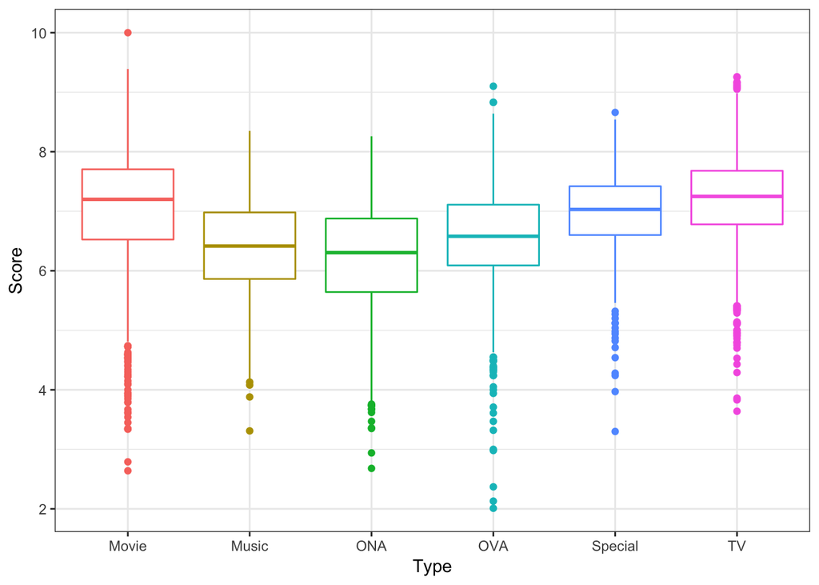

```r
plot1 <- ggplot(AnimeInfo_df) +
    geom_boxplot(aes(y=Score, x= Type, color = Type)) +
    theme_bw() + theme(legend.position="none")
plot1
```

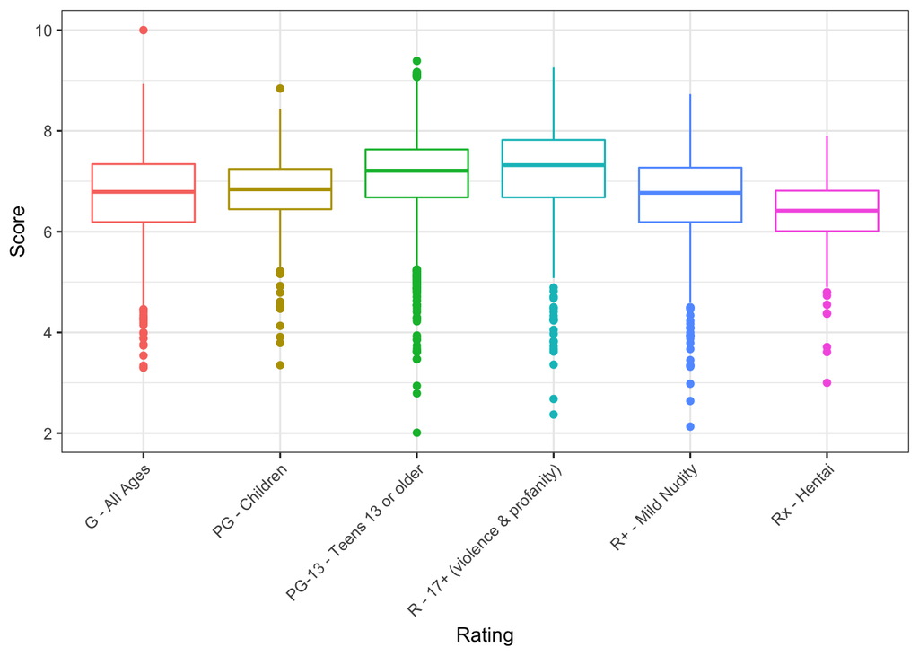

```r
plot2 <- ggplot(AnimeInfo_df) +
    geom_boxplot(aes(y=Score, x= Rating, color = Rating)) +
    theme_bw() +
    theme(axis.text.x = element_text(angle = 45, hjust = 1),
          legend.position="none")
plot2
```

```r
# dummify director variable
# list of anime directors who won awards in last 15-20 years at Tokyo Anime Award or Animation Kobe
direct_award <- c("Daichi, Akitaro", "Miyazaki, Hayao", "Hara, Keiichi", "Kon, Satoshi",
                  "Miyazaki, Hayao", "Tomino, Yoshiyuki", "Hosoda, Mamoru", "Anno, Hideaki",
                  "Miyazaki, Hayao", "Hosoda, Mamoru", "Yonebayashi, Hiromasa", "Shinbo, Akiyuki",
                  "Hosoda, Mamoru", "Araki, Tetsuro", "Takahata, Isao", "Fujita, Yōichi",
                  "Anno, Hideaki", "Miyazaki, Hayao", "Watanabe, Shinichi", "Daichi, Akitaro",
                  "Okiura, Hiroyuki", "Kitakubo, Hiroyuki", "Hara, Keiichi", "Kuroda, Yosuke",
                  "Kamiyama, Kenji", "Yoshida, Kenichi", "Nagahama, Hiroshi", "Imaishi, Hiroyuki",
                  "Iso, Mitsuo", "Kato, Kunio", "Hosoda, Mamoru", "Okada, Mari",
                  "Agematsu, Noriyasu", "Mizushima, Tsutomu","Kishi, Seiji", "Mizushima, Seiji")
direct_award <- unique(direct_award)
AnimeInfo_df$Award_Director <- ifelse(AnimeInfo_df$Director %in% direct_award, TRUE, FALSE)
## didn't have enough time to do the same thing on actors and musicians
##multi-variable linear regression
model <- glm(Score ~ Award_Director + Viewer + Favorite + Type + Rating, data = AnimeInfo_df)
summary(model)
```

```
##
## Call:
## glm(formula = Score ~ Award_Director + Viewer + Favorite + Type +
##     Rating, data = AnimeInfo_df)
##
## Deviance Residuals:
##     Min       1Q   Median       3Q      Max
## -4.7681  -0.3781   0.0714   0.4819   3.2648
##
## Coefficients:
##                                        Estimate Std. Error t value
## (Intercept)                           6.735e+00  3.486e-02 193.173
## Award_DirectorTRUE                    3.733e-01  5.212e-02   7.163
## Viewer                                5.395e-06  2.327e-07  23.182
## Favorite                             -3.646e-05  5.283e-06  -6.901
## TypeMusic                            -5.566e-01  8.036e-02  -6.926
## TypeONA                              -7.764e-01  5.816e-02 -13.349
## TypeOVA                              -2.281e-01  3.493e-02  -6.530
## TypeSpecial                           5.017e-03  3.966e-02   0.127
## TypeTV                                1.777e-02  3.040e-02   0.584
## RatingPG - Children                  -8.318e-03  4.906e-02  -0.170
## RatingPG-13 - Teens 13 or older       2.321e-01  3.262e-02   7.115
## RatingR - 17+ (violence & profanity)  1.474e-01  4.143e-02   3.559
## RatingR+ - Mild Nudity               -1.865e-01  4.274e-02  -4.364
## RatingRx - Hentai                    -1.337e-01  4.632e-02  -2.886
##                                      Pr(>|t|)
## (Intercept)                           < 2e-16 ***
## Award_DirectorTRUE                   8.82e-13 ***
## Viewer                                < 2e-16 ***
## Favorite                             5.72e-12 ***
## TypeMusic                            4.80e-12 ***
## TypeONA                               < 2e-16 ***
## TypeOVA                              7.12e-11 ***
## TypeSpecial                          0.899335
## TypeTV                               0.558947
## RatingPG - Children                  0.865357
## RatingPG-13 - Teens 13 or older      1.25e-12 ***
## RatingR - 17+ (violence & profanity) 0.000375 ***
## RatingR+ - Mild Nudity               1.30e-05 ***
## RatingRx - Hentai                    0.003916 **
## ---
## Signif. codes:  0 '***' 0.001 '**' 0.01 '*' 0.05 '.' 0.1 ' ' 1
##
## (Dispersion parameter for gaussian family taken to be 0.5564911)
##
##     Null deviance: 4651.4  on 5952  degrees of freedom
## Residual deviance: 3305.0  on 5939  degrees of freedom
## AIC: 13421
##
## Number of Fisher Scoring iterations: 2
```

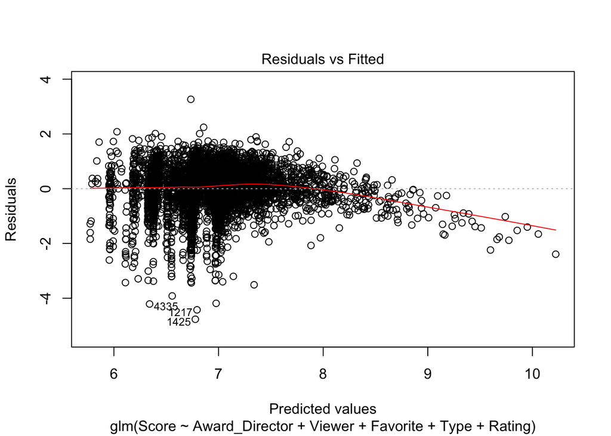

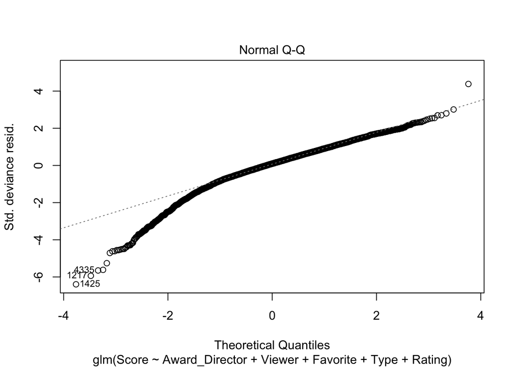

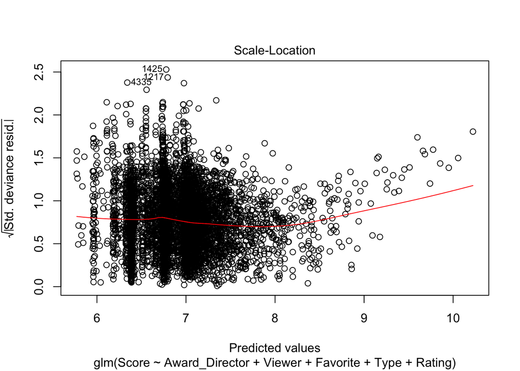

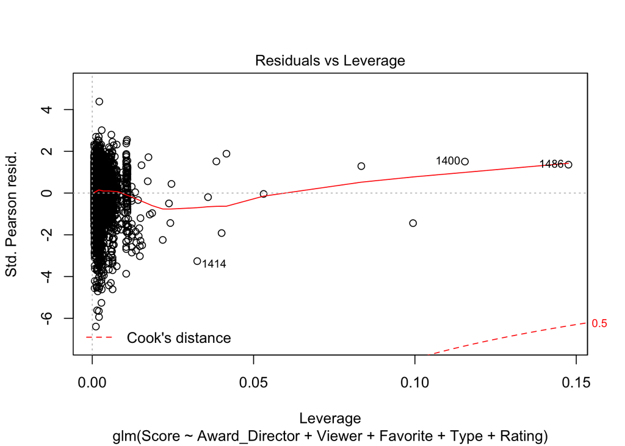

```r
plot(model)
```

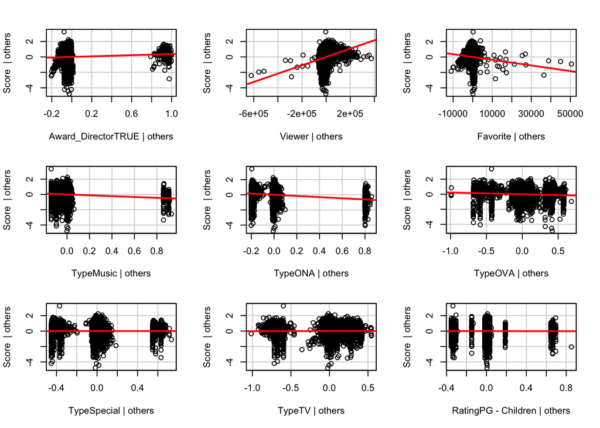

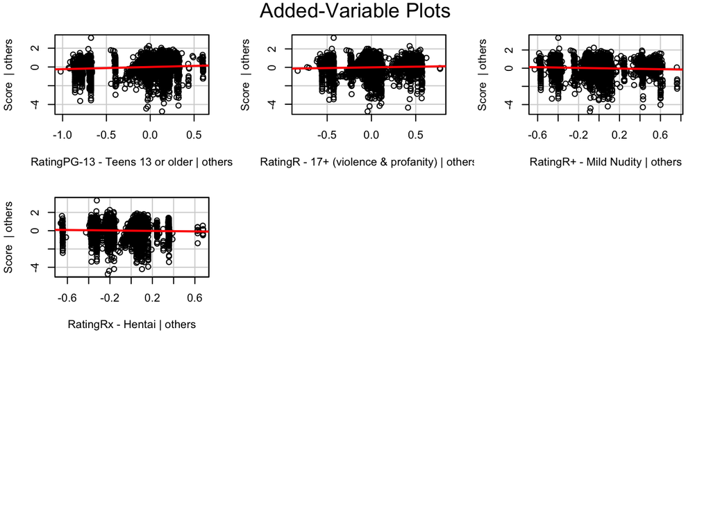

```r
avPlots(model)
```

```r
vif(model)
```

```
##                    GVIF Df GVIF^(1/(2*Df))
## Award_Director 1.025117  1        1.012481
## Viewer         3.089501  1        1.757698
## Favorite       2.654953  1        1.629403
## Type           1.853266  5        1.063638
## Rating         1.751659  5        1.057657
```

Significant coeffiecients: (Intercept), Award_DirectorTRUE, Favorite, Viewer, TypeMusic, TypeONA, TypeOVA, RatingPG-13 - Teens 13 or older, RatingR - 17+ (violence & profanity), RatingR+ - Mild Nudity, RatingRx - Hentai.

Adjusted R-squared: 0.289 only explains 28.9% of the variance in scores of animes.

To do:  
- Normalize viewer/favorites against time since release;  
- Use number of favorites on staff/actor pages to turn Director, Actor etc. into continuous variable.

```r
people_df <- read.csv("AnimePeople/AnimePeople.csv", header = T, stringsAsFactors = F)
df<-AnimeInfo_df
df$DirectorScore <- 0
df$ActorScore <- 0
df$MusicianScore <- 0
for (i in c(1:nrow(df))){
    if(!is.na(df$Director[i])){
        df$DirectorScore[i] <- people_df$anime_people_fav[which(people_df$anime_people == df$Director[i])[1]]
    }
    if(!is.na(df$Musician[i])){
        df$MusicianScore[i] <- people_df$anime_people_fav[which(people_df$anime_people == df$Musician[i])[1]]
    }
    if(!is.na(df$Actor1[i])){
        df$ActorScore[i] <- df$ActorScore[i] + people_df$anime_people_fav[which(people_df$anime_people == df$Actor1[i])[1]]
    }
    if(!is.na(df$Actor2[i])){
        df$ActorScore[i] <- df$ActorScore[i] + people_df$anime_people_fav[which(people_df$anime_people == df$Actor2[i])[1]]
    }
    if(!is.na(df$Actor3[i])){
        df$ActorScore[i] <- df$ActorScore[i] + people_df$anime_people_fav[which(people_df$anime_people == df$Actor3[i])[1]]
    }
    if(!is.na(df$Actor4[i])){
        df$ActorScore[i] <- df$ActorScore[i] + people_df$anime_people_fav[which(people_df$anime_people == df$Actor4[i])[1]]
    }
}
#model_lm <- lm(Score ~ ..., data = df)
#after many trials, linear model still doesn't work
#use random forest
```

```r
new_df <- readRDS("final_df.RDS")
library(randomForest)
set.seed(0)
train <- sample(c(1:nrow(new_df)), 0.8*nrow(new_df))
rf_df <- randomForest(Score ~ DirectorScore + ActorScore + MusicianScore + Viewer + Favorite + Type + Rating, data = new_df, subset = train, importance = TRUE)
set.seed(0)
oob.err <- numeric(7)
for (mtry in 1:7) {
    fit <- randomForest(Score ~ . - Title , data = new_df[train, ], mtry = mtry)
    oob.err[mtry] <- fit$mse[500]
    cat("We're performing iteration", mtry, "\n")
}
```

```
## We're performing iteration 1
## We're performing iteration 2
## We're performing iteration 3
## We're performing iteration 4
## We're performing iteration 5
## We're performing iteration 6
## We're performing iteration 7
```

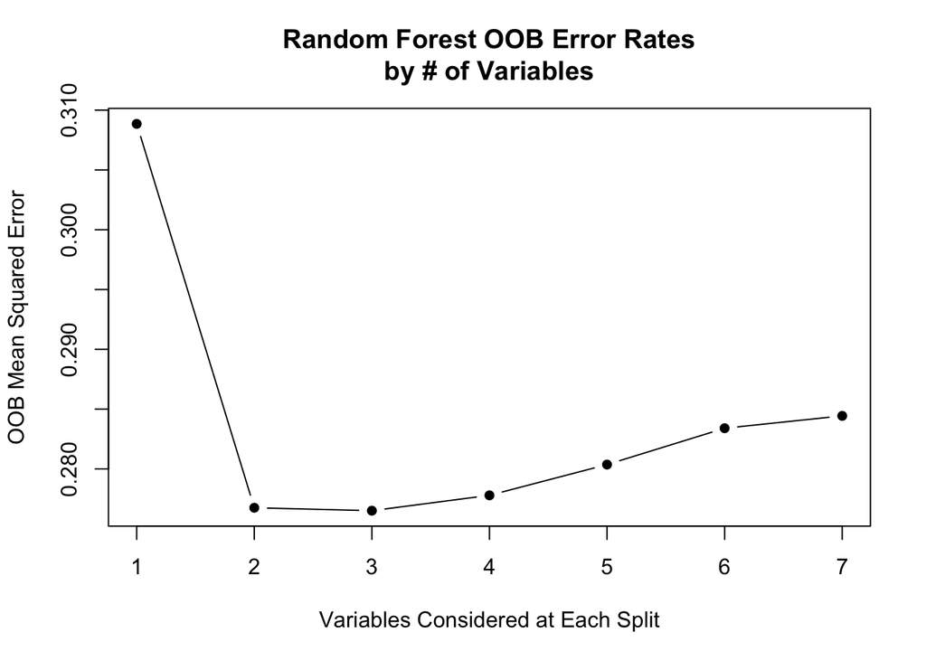

```r
plot(1:7, oob.err, pch = 16, type = "b",
     xlab = "Variables Considered at Each Split",
     ylab = "OOB Mean Squared Error",
     main = "Random Forest OOB Error Rates\nby # of Variables")
```

```r
min(oob.err)
```

```
## [1] 0.2765093
```

```r
which.min(oob.err)
```

```
## [1] 3
```

```r
importance(rf_df, type = 1)
```

```
##                %IncMSE
## DirectorScore 30.64382
## ActorScore    44.65084
## MusicianScore 26.36350
## Viewer        53.04153
## Favorite      66.95043
## Type          67.82751
## Rating        49.92500
```

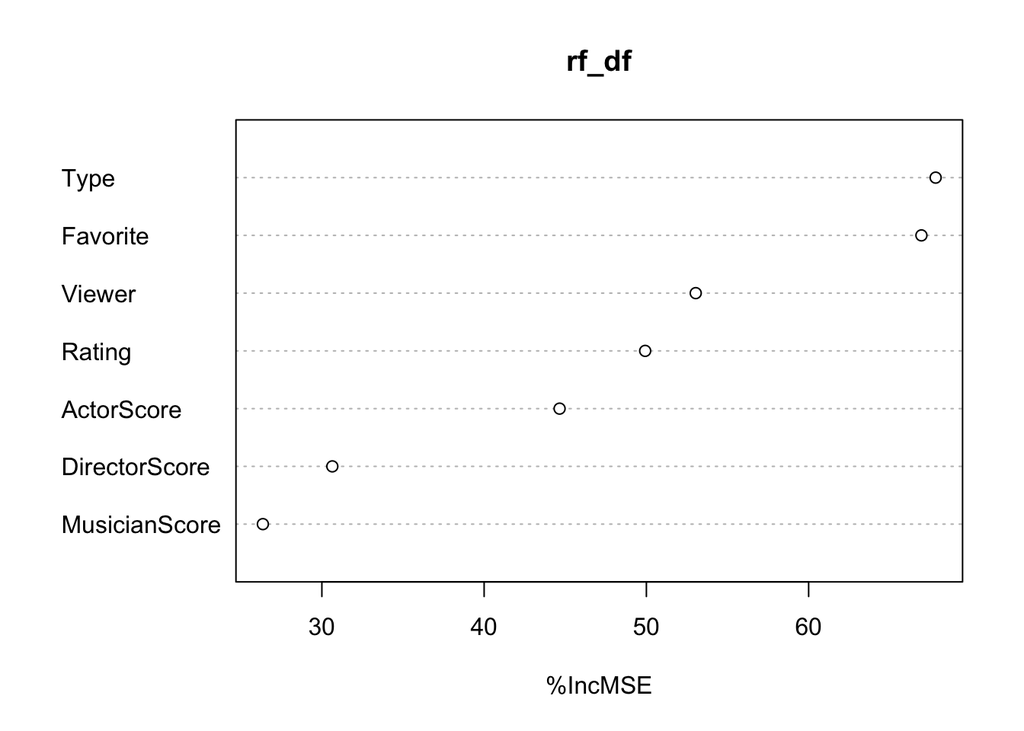

```r
varImpPlot(rf_df, type = 1)
```

```r
rf_df_final <- randomForest(Score ~ DirectorScore +
                                ActorScore + MusicianScore +
                                Viewer + Favorite + Type +
                                Rating,
                            data = new_df,
                            subset = train,
                            mtry = 3)
pred_test <- predict(rf_df_final, new_df[-train,])
Metrics::rmse(new_df$Score[-train], pred_test)
```

```
## [1] 0.5842004
```